# Red Wine EDA by Terry Li

```r
# Load all of the packages that you end up using
# in your analysis in this code chunk.

# Notice that the parameter "echo" was set to FALSE for this code chunk.
# This prevents the code from displaying in the knitted HTML output.
# You should set echo=TRUE for all code chunks in your file.

library(ggplot2)
library(ggthemes)
library(dplyr)
library(gridExtra)
library(tidyr)
library(RColorBrewer)
library(GGally)
```

```r
# Load the Data
setwd('/Users/Terry/Udacity/P4/P4 Project/')
wine <- read.csv('wineQualityReds.csv', header = T)
```

This report explores a dataset containing quality rating and attributes for approximately 1,600 wines.

# 1 Univariate Plots Section

```r
dim(wine)
```

```
## [1] 1599   13
```

```r
summary(wine)
```

```
##        X          fixed.acidity   volatile.acidity  citric.acid
##  Min.   :   1.0   Min.   : 4.60   Min.   :0.1200   Min.   :0.000
##  1st Qu.: 400.5   1st Qu.: 7.10   1st Qu.:0.3900   1st Qu.:0.090
##  Median : 800.0   Median : 7.90   Median :0.5200   Median :0.260
##  Mean   : 800.0   Mean   : 8.32   Mean   :0.5278   Mean   :0.271
##  3rd Qu.:1199.5   3rd Qu.: 9.20   3rd Qu.:0.6400   3rd Qu.:0.420
##  Max.   :1599.0   Max.   :15.90   Max.   :1.5800   Max.   :1.000
##  residual.sugar     chlorides       free.sulfur.dioxide
##  Min.   : 0.900   Min.   :0.01200   Min.   : 1.00
##  1st Qu.: 1.900   1st Qu.:0.07000   1st Qu.: 7.00
##  Median : 2.200   Median :0.07900   Median :14.00
##  Mean   : 2.539   Mean   :0.08747   Mean   :15.87
##  3rd Qu.: 2.600   3rd Qu.:0.09000   3rd Qu.:21.00
##  Max.   :15.500   Max.   :0.61100   Max.   :72.00
##  total.sulfur.dioxide    density             pH          sulphates
##  Min.   :  6.00       Min.   :0.9901   Min.   :2.740   Min.   :0.3300
##  1st Qu.: 22.00       1st Qu.:0.9956   1st Qu.:3.210   1st Qu.:0.5500
##  Median : 38.00       Median :0.9968   Median :3.310   Median :0.6200
##  Mean   : 46.47       Mean   :0.9967   Mean   :3.311   Mean   :0.6581
##  3rd Qu.: 62.00       3rd Qu.:0.9978   3rd Qu.:3.400   3rd Qu.:0.7300
##  Max.   :289.00       Max.   :1.0037   Max.   :4.010   Max.   :2.0000
##     alcohol         quality
##  Min.   : 8.40   Min.   :3.000
##  1st Qu.: 9.50   1st Qu.:5.000
##  Median :10.20   Median :6.000
##  Mean   :10.42   Mean   :5.636
##  3rd Qu.:11.10   3rd Qu.:6.000
##  Max.   :14.90   Max.   :8.000
```

```r
str(wine)
```

```
## 'data.frame':    1599 obs. of  13 variables:
##  $ X                   : int  1 2 3 4 5 6 7 8 9 10 ...
##  $ fixed.acidity       : num  7.4 7.8 7.8 11.2 7.4 7.4 7.9 7.3 7.8 7.5 ...
##  $ volatile.acidity    : num  0.7 0.88 0.76 0.28 0.7 0.66 0.6 0.65 0.58 0.5 ...
##  $ citric.acid         : num  0 0 0.04 0.56 0 0 0.06 0 0.02 0.36 ...
##  $ residual.sugar      : num  1.9 2.6 2.3 1.9 1.9 1.8 1.6 1.2 2 6.1 ...
##  $ chlorides           : num  0.076 0.098 0.092 0.075 0.076 0.075 0.069 0.065 0.073 0.071 ...
##  $ free.sulfur.dioxide : num  11 25 15 17 11 13 15 15 9 17 ...
##  $ total.sulfur.dioxide: num  34 67 54 60 34 40 59 21 18 102 ...
##  $ density             : num  0.998 0.997 0.997 0.998 0.998 ...
##  $ pH                  : num  3.51 3.2 3.26 3.16 3.51 3.51 3.3 3.39 3.36 3.35 ...
##  $ sulphates           : num  0.56 0.68 0.65 0.58 0.56 0.56 0.46 0.47 0.57 0.8 ...
##  $ alcohol             : num  9.4 9.8 9.8 9.8 9.4 9.4 9.4 10 9.5 10.5 ...
##  $ quality             : int  5 5 5 6 5 5 5 7 7 5 ...
```

It is noted that 3/4 of the wines were rated 6 or below with the range from 3 to 8. It is believed that the wines were rated on a 10-point scale. It is believed that there were to extreme rating (1, 2, 9 and 10) because they were calculated by taking the median of the ratings from three experts.

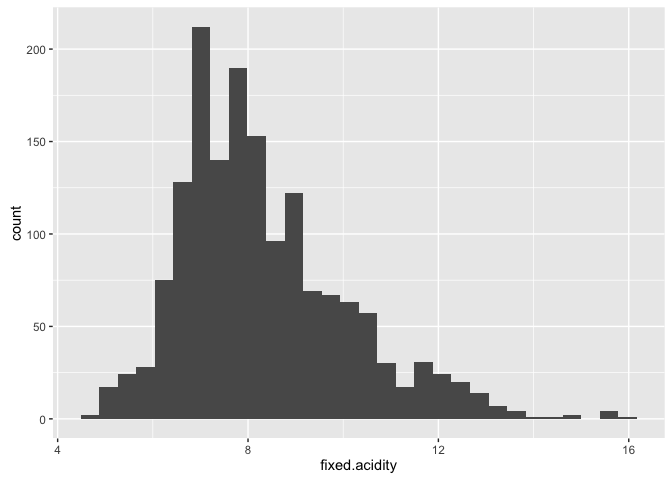

```r
ggplot(aes(x = fixed.acidity), data = wine) +
  geom_histogram()
```

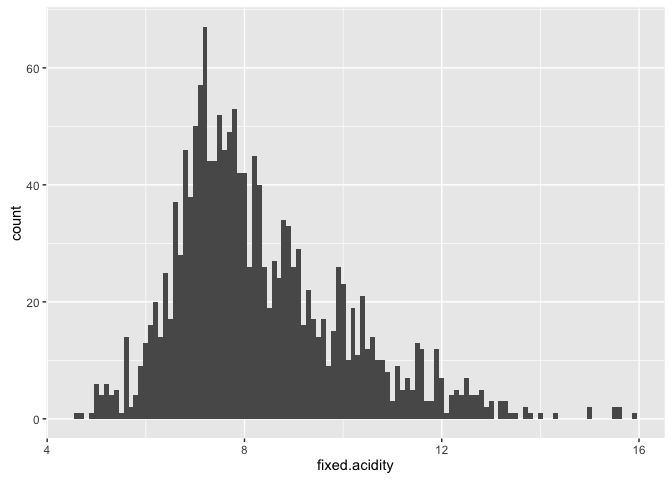

```r
ggplot(aes(x = fixed.acidity), data = wine) +
  geom_histogram(binwidth = 0.1)
```

```r
summary(wine$fixed.acidity)
```

```
##    Min. 1st Qu.  Median    Mean 3rd Qu.    Max.
##    4.60    7.10    7.90    8.32    9.20   15.90
```

The variable `fixed acidity` looked kind of normal with right-skewed shape.

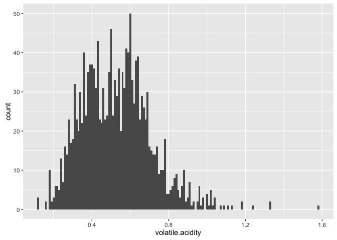

```r
ggplot(aes(x = volatile.acidity), data = wine) +
  geom_histogram(binwidth = 0.01)
```

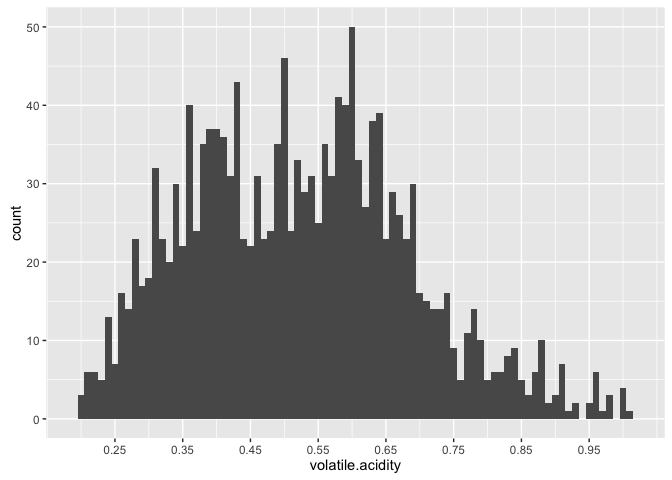

```r
ggplot(aes(x = volatile.acidity), data = wine) +
  geom_histogram(binwidth = 0.01) +
  scale_x_continuous(limits = c(quantile(wine$volatile.acidity, 0.01), quantile(wine$volatile.acidity, 0.99)), breaks = seq(0.25, 1, 0.1))
```

```r
theme_set(theme_minimal(10))

summary(wine$volatile.acidity)
```

```
##    Min. 1st Qu.  Median    Mean 3rd Qu.    Max.
##  0.1200  0.3900  0.5200  0.5278  0.6400  1.5800
```

The variable `volatile acidity` looked kind of bimodal with right-skewed shape. As there are some outliners on both ends, the x axis is adjusted to exlcude them for a closer look.

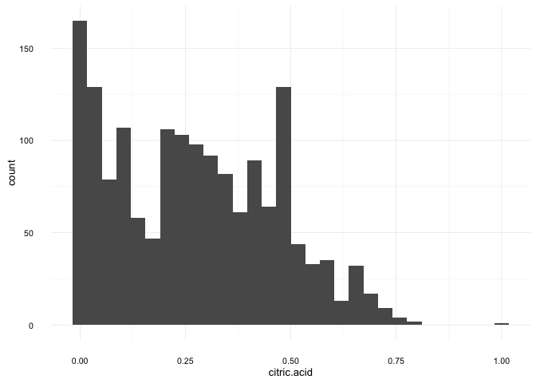

```r
ggplot(aes(x = citric.acid), data = wine) +
  geom_histogram()
```

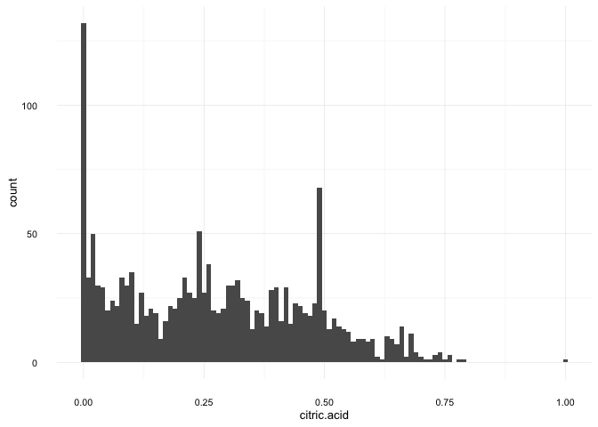

```r
ggplot(aes(x = citric.acid), data = wine) +
  geom_histogram(binwidth = 0.01)
```

```r
summary(wine$citric.acid)
```

```
##    Min. 1st Qu.  Median    Mean 3rd Qu.    Max.
##   0.000   0.090   0.260   0.271   0.420   1.000
```

For variable `citric acid`, it is unexpected to noted that the mode is 0.00 and such mode is very outstanding. The second most common value, which is 0.49, is also very outstanding.

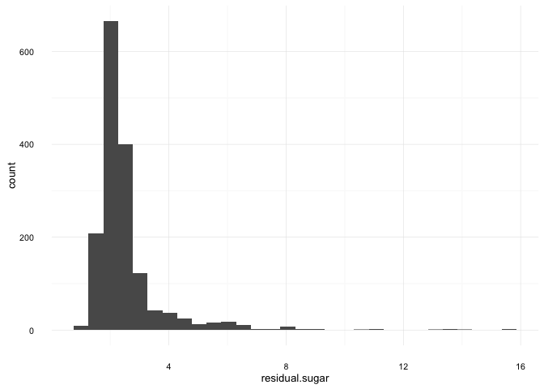

```r
ggplot(aes(x = residual.sugar), data = wine) +
  geom_histogram()
```

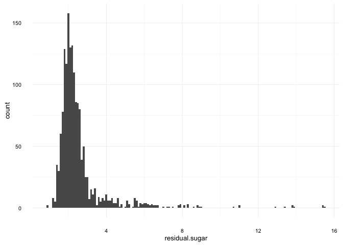

```r
ggplot(aes(x = residual.sugar), data = wine) +
  geom_histogram(binwidth = 0.1)
```

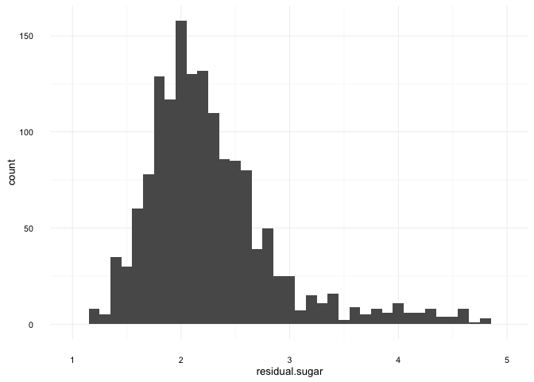

```r
ggplot(aes(x = residual.sugar), data = wine) +
  geom_histogram(binwidth = 0.1) +
  xlim(1, 5)
```

```r
summary(wine$residual.sugar)
```

```
##    Min. 1st Qu.  Median    Mean 3rd Qu.    Max.
##   0.900   1.900   2.200   2.539   2.600  15.500
```

The variable `residual sugar` looked kind of normal with right-skewed shape.

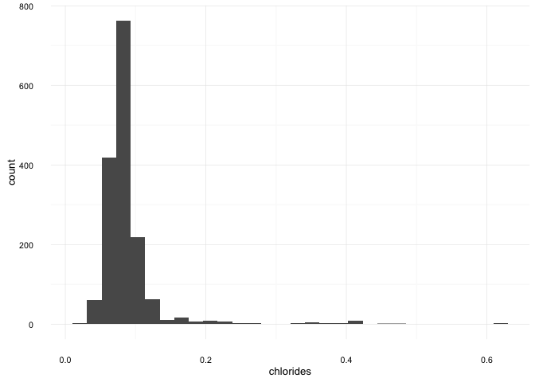

```r
ggplot(aes(x = chlorides), data = wine) +
  geom_histogram()
```

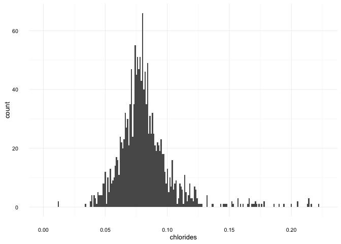

```r
ggplot(aes(x = chlorides), data = wine) +
  geom_histogram(binwidth = 0.001) +
  xlim(0, quantile(wine$chlorides, 0.98))
```

```r
summary(wine$chlorides)
```

```
##    Min. 1st Qu.  Median    Mean 3rd Qu.    Max.
## 0.01200 0.07000 0.07900 0.08747 0.09000 0.61100
```

The variable `chlorides` looked kind of normal with lightly right-skewed shape.

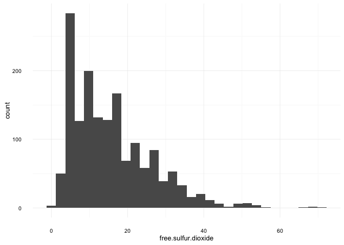

```r
ggplot(aes(x = free.sulfur.dioxide), data = wine) +
  geom_histogram()
```

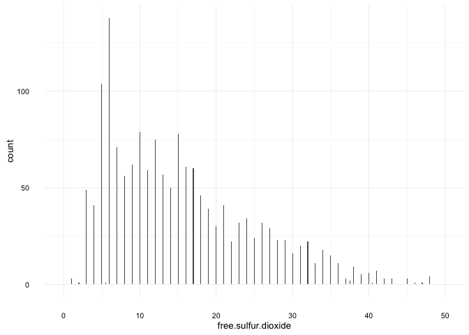

```r
ggplot(aes(x = free.sulfur.dioxide), data = wine) +
  geom_histogram(binwidth = 0.1) +
  xlim(0, quantile(wine$free.sulfur.dioxide, 0.99))
```

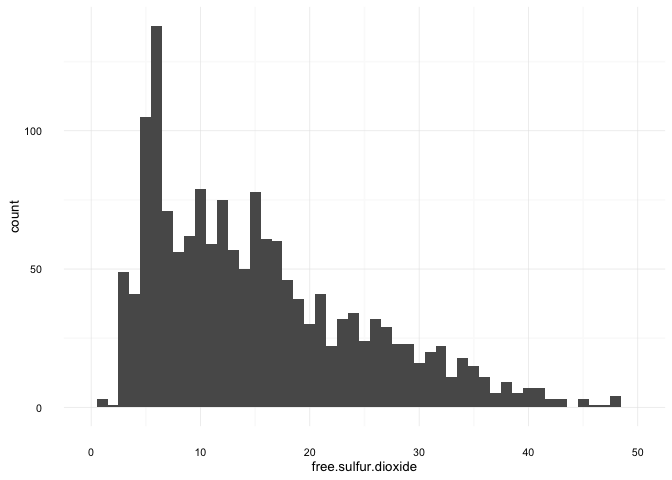

```r
ggplot(aes(x = free.sulfur.dioxide), data = wine) +
  geom_histogram(binwidth = 1) +
  xlim(0, quantile(wine$free.sulfur.dioxide, 0.99))
```

```r
summary(wine$free.sulfur.dioxide)
```

```
##    Min. 1st Qu.  Median    Mean 3rd Qu.    Max.
##    1.00    7.00   14.00   15.87   21.00   72.00
```

The variable `free sulfur dioxide` is integer and right skewed. Furthermore, there are few outliners.

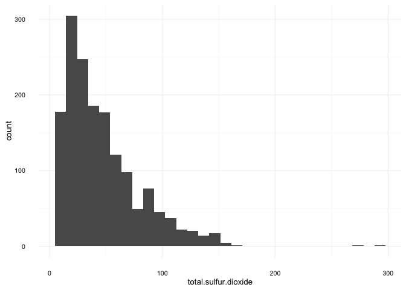

```r
ggplot(aes(x = total.sulfur.dioxide), data = wine) +
  geom_histogram()
```

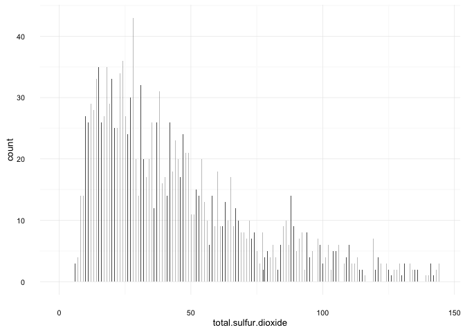

```r
ggplot(aes(x = total.sulfur.dioxide), data = wine) +
  geom_histogram(binwidth = 0.1) +
  xlim(0, quantile(wine$total.sulfur.dioxide, 0.99))
```

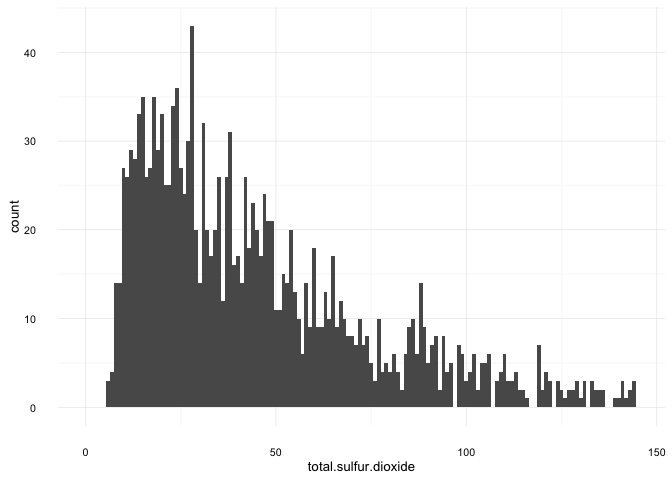

```r
ggplot(aes(x = total.sulfur.dioxide), data = wine) +
  geom_histogram(binwidth = 1) +
  xlim(0, quantile(wine$total.sulfur.dioxide, 0.99))
```

```r
summary(wine$total.sulfur.dioxide)
```

```
##    Min. 1st Qu.  Median    Mean 3rd Qu.    Max.
##    6.00   22.00   38.00   46.47   62.00  289.00
```

The variable `total sulfur dioxide` is also integer and right skewed. Furthermore, there are 2 outliners.

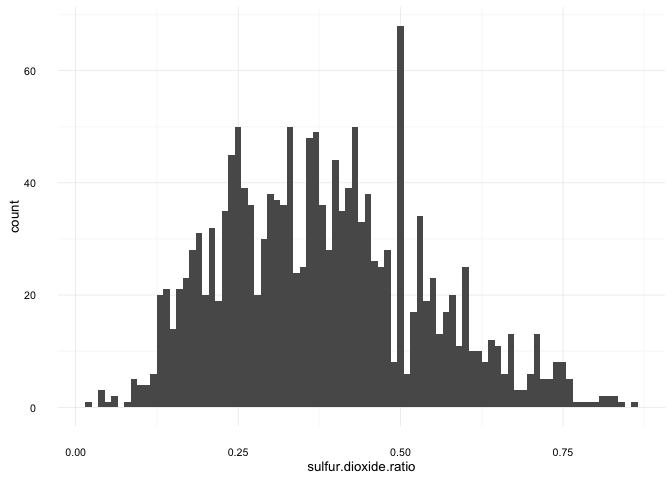

```r
wine$sulfur.dioxide.ratio <- with(wine, free.sulfur.dioxide / total.sulfur.dioxide)

ggplot(aes(x = sulfur.dioxide.ratio), data = wine) +
  geom_histogram(binwidth = 0.01)
```

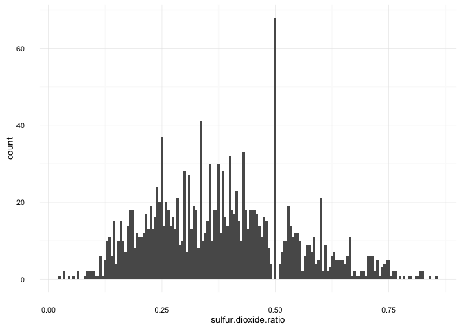

```r
ggplot(aes(x = sulfur.dioxide.ratio), data = wine) +
  geom_histogram(binwidth = 0.005)
```

```r
summary(wine$sulfur.dioxide.ratio)
```

```
##    Min. 1st Qu.  Median    Mean 3rd Qu.    Max.
## 0.02273 0.25930 0.37500 0.38230 0.48480 0.85710
```

A new variable `sulfur dioxide ratio` was created. It is interesting to note that the mode is 0.5 and very outstanding while the adjacent values are quite low in count.

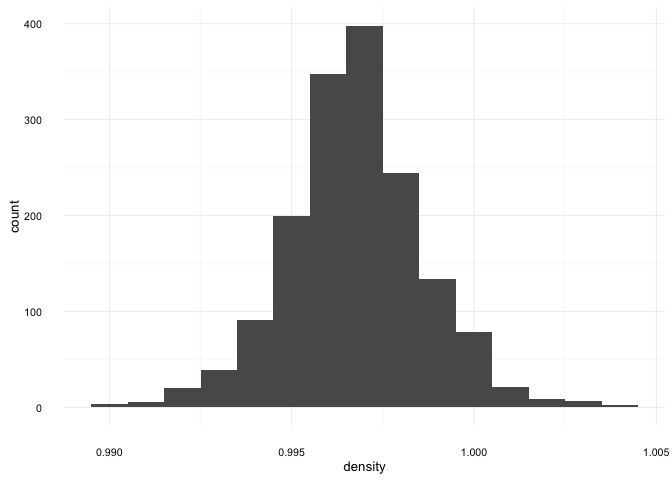

```r
ggplot(aes(x = density), data = wine) +
  geom_histogram(binwidth = 0.001)
```

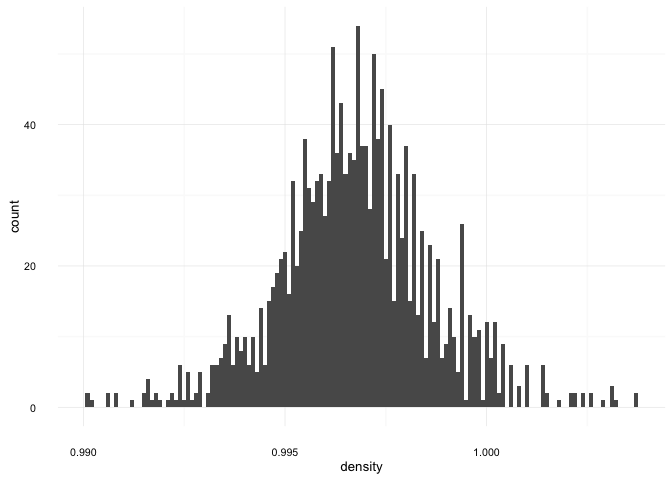

```r
ggplot(aes(x = density), data = wine) +
  geom_histogram(binwidth = 0.0001)
```

```r
summary(wine$density)
```

```
##    Min. 1st Qu.  Median    Mean 3rd Qu.    Max.
##  0.9901  0.9956  0.9968  0.9967  0.9978  1.0040
```

The vairable `density` is a normal distribution and the range is quite small (from 0.9901 to 1.0040).

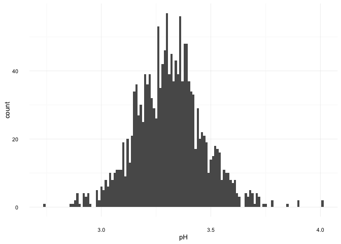

```r
ggplot(aes(x = pH), data = wine) +
  geom_histogram(binwidth = 0.01)
```

```r
summary(wine$pH)
```

```
##    Min. 1st Qu.  Median    Mean 3rd Qu.    Max.
##   2.740   3.210   3.310   3.311   3.400   4.010
```

The vairable `pH` is a normal distribution and the range is quite small. The range (from 2.740 to 4.010) is in line with my understanding.

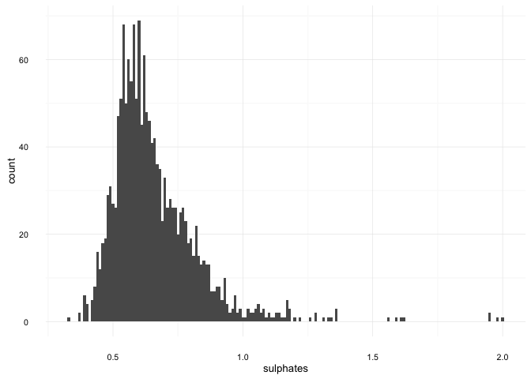

```r
ggplot(aes(x = sulphates), data = wine) +
  geom_histogram(binwidth = 0.01)
```

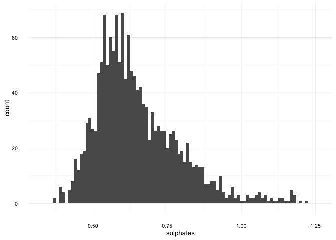

```r
ggplot(aes(x = sulphates),  data = wine) +
  geom_histogram(binwidth = 0.01) +
  xlim(min(wine$sulphates), quantile(wine$sulphates, 0.99))
```

```r
summary(wine$sulphates)
```

```
##    Min. 1st Qu.  Median    Mean 3rd Qu.    Max.
##  0.3300  0.5500  0.6200  0.6581  0.7300  2.0000
```

The variable `sulphates` looked kind of normal with lightly right-skewed shape.

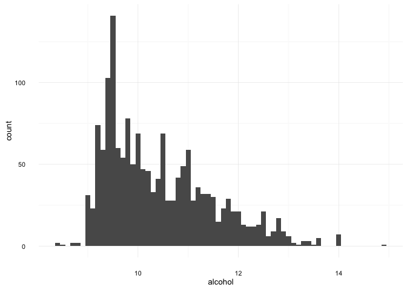

```r
ggplot(aes(x = alcohol), data = wine) +
  geom_histogram(binwidth = 0.1)
```

```r
summary(wine$alcohol)
```

```
##    Min. 1st Qu.  Median    Mean 3rd Qu.    Max.
##    8.40    9.50   10.20   10.42   11.10   14.90
```

The variable `alcohol` is right-skewed.

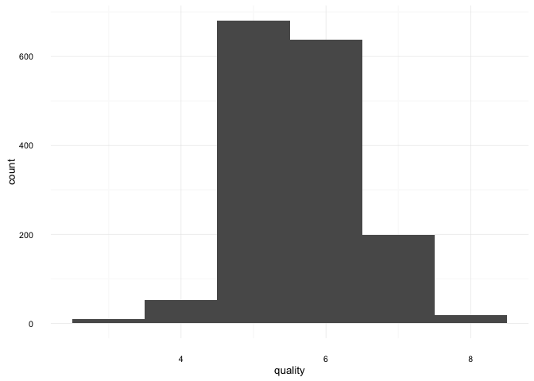

```r
ggplot(aes(x = quality), data = wine) +
  geom_histogram(binwidth = 1)
```

```r
summary(wine$quality)
```

```
##    Min. 1st Qu.  Median    Mean 3rd Qu.    Max.
##   3.000   5.000   6.000   5.636   6.000   8.000
```

```r
summary(factor(wine$quality))
```

```
##   3   4   5   6   7   8
##  10  53 681 638 199  18
```

The variable `quality` is an integer with 5 and 6 as the most common value.

# 2 Univariate Analysis

### 2.0.1 What is the structure of your dataset?

The data set contains 1,599 observations with 13 features. All of them are numerical values except X (the ID of each observation) and quality.

### 2.0.2 What is/are the main feature(s) of interest in your dataset?

The main feature of interest is the `quality` rating. I would like to determine which features are best for predicting the quality of a wine.

### 2.0.3 What other features in the dataset do you think will help support your investigation into your feature(s) of interest?

While I am not a winer drinker, my guess would be the volatile acidity, fixed acidity,and citric acid and residual suger.

### 2.0.4 Did you create any new variables from existing variables in the dataset?

Yes I created `sulfur.dioxide.ratio`.

### 2.0.5 Of the features you investigated, were there any unusual distributions? Did you perform any operations on the data to tidy, adjust, or change the form of the data? If so, why did you do this?

As documented above, citric acid has a unusual distribution; the mode is 0.00 and the second most common value which is 0.49, and both of them are very outstanding compaed to the other observed values.

As this is a tidy dataset, no operations were performed to tidy, adjust, or change the form of the data.

# 3 Bivariate Plots Section

## 3.1 Pairwise plot matrix

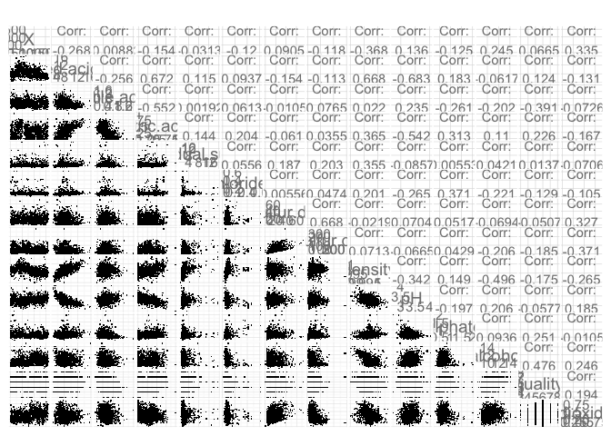

```r
ggpairs(wine, axisLabels = 'internal',
  lower = list(continuous = wrap("points", shape = I('.'))),
  upper = list(combo = wrap("box", outlier.shape = I('.'))))
```

I think that `ggairs()` is the most efficient way to get a feel for potential relationships in the data. All the observations are used as there the number of observations is not large.

It seems to me that there are not many strong corrleation in the data, especially those related to quality. The top correlations involving quality are as follows: - alcohol (0.476) - volatile acidity (-0.391) - sulphates (0.251) - citric acid (0.226)

## 3.2 Quality vs Alcohol

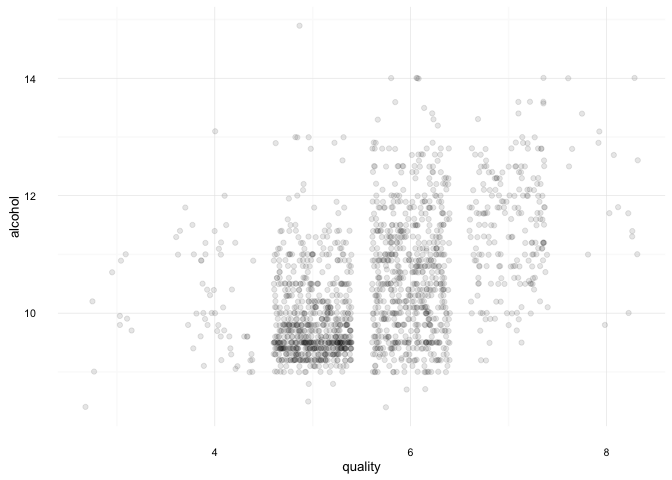

```r
ggplot(aes(x = quality, y = alcohol), data = wine) +
  geom_jitter(alpha = 1/10, position = 'jitter')
```

```r
with(wine, by(alcohol, factor(quality), summary))
```

```
## factor(quality): 3
##    Min. 1st Qu.  Median    Mean 3rd Qu.    Max.
##   8.400   9.725   9.925   9.955  10.580  11.000
## --------------------------------------------------------
## factor(quality): 4
##    Min. 1st Qu.  Median    Mean 3rd Qu.    Max.
##    9.00    9.60   10.00   10.27   11.00   13.10
## --------------------------------------------------------
## factor(quality): 5
##    Min. 1st Qu.  Median    Mean 3rd Qu.    Max.
##     8.5     9.4     9.7     9.9    10.2    14.9
## --------------------------------------------------------
## factor(quality): 6
##    Min. 1st Qu.  Median    Mean 3rd Qu.    Max.
##    8.40    9.80   10.50   10.63   11.30   14.00
## --------------------------------------------------------
## factor(quality): 7
##    Min. 1st Qu.  Median    Mean 3rd Qu.    Max.
##    9.20   10.80   11.50   11.47   12.10   14.00
## --------------------------------------------------------
## factor(quality): 8
##    Min. 1st Qu.  Median    Mean 3rd Qu.    Max.
##    9.80   11.32   12.15   12.09   12.88   14.00
```

```r
with(wine, by(alcohol, factor(quality), IQR))
```

```
## factor(quality): 3
## [1] 0.85
## --------------------------------------------------------
## factor(quality): 4
## [1] 1.4
## --------------------------------------------------------
## factor(quality): 5
## [1] 0.8
## --------------------------------------------------------
## factor(quality): 6
## [1] 1.5
## --------------------------------------------------------
## factor(quality): 7
## [1] 1.3
## --------------------------------------------------------
## factor(quality): 8
## [1] 1.55
```

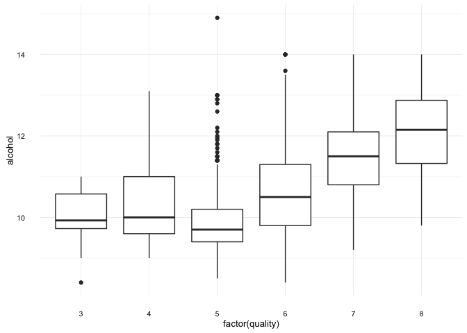

```r
ggplot(aes(x = factor(quality), y = alcohol), data = wine) +
  geom_boxplot()
```

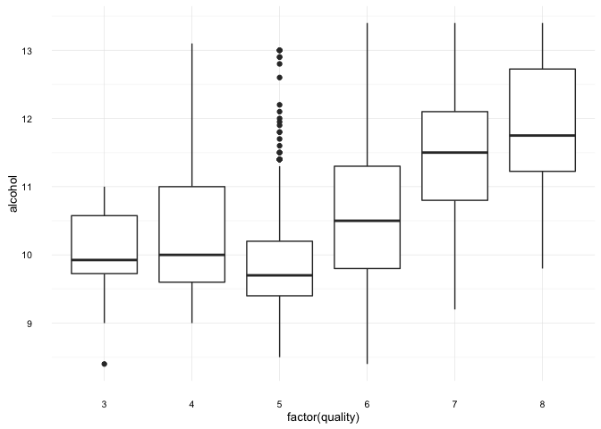

```r
ggplot(aes(x = factor(quality), y = alcohol), data = wine) +
  geom_boxplot() +
  ylim(min(wine$alcohol), quantile(wine$alcohol, 0.99))
```

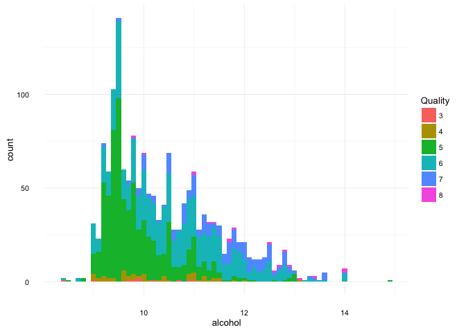

```r
ggplot(aes(x = alcohol), data = wine) +
  geom_histogram(aes(fill = factor(quality)), binwidth = 0.1) +
  scale_color_brewer(type = 'div', name = 'Quality') +
  scale_fill_discrete(name = 'Quality')
```